# Project Part I - Dataset Exploration of Loan Data from Prosper, a Peer-to-Peer Loan Facilitation Company.

**Question 9:**

- What is the profitability of these loans to investors?

*Let us explore the Lender Yield distribution*

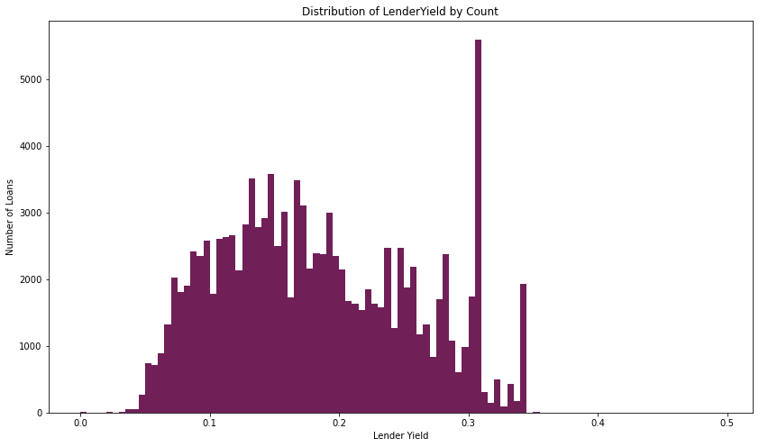

```python
plt.figure(figsize=(14,8))
linear_histogram(x='LenderYield', xlabel='Lender Yield', binsize=0.005)
```

*Observation:*

- Prosper loans are quite profitable, with most of them having a profitabilty of between 10% and 25%.
- A small number of loans (about 5000+) have a yield of 31%.

*Does it correspond to the same spike in loans with borrower rates of about 32%? Why?*

```python
loan_df_subset_copy.info()
```

```
<class 'pandas.core.frame.DataFrame'>
RangeIndex: 113937 entries, 0 to 113936
Data columns (total 21 columns):
 #   Column                       Non-Null Count   Dtype
---  ------                       --------------   -----
 0   ListingNumber                113937 non-null  int64
 1   ListingCreationDate          113937 non-null  datetime64[ns]
 2   Term                         113937 non-null  int64
 3   LoanStatus                   113937 non-null  category
 4   BorrowerState                108422 non-null  object
 5   Occupation                   110349 non-null  object
 6   EmploymentStatus             113937 non-null  category
 7   EmploymentStatusDuration     106312 non-null  float64
 8   IsBorrowerHomeowner          113937 non-null  bool
 9   DebtToIncomeRatio            105383 non-null  float64
 10  IncomeRange                  113937 non-null  category
 11  IncomeVerifiable             113937 non-null  bool
 12  StatedMonthlyIncome          113937 non-null  float64
 13  BorrowerAPR                  113912 non-null  float64
 14  BorrowerRate                 113937 non-null  float64
 15  LenderYield                  113937 non-null  float64
 16  ListingCategory              113937 non-null  category
 17  InvestmentFromFriendsCount   113937 non-null  int64
 18  InvestmentFromFriendsAmount  113937 non-null  float64
 19  Investors                    113937 non-null  int64
 20  Credit_Rating                113937 non-null  category
dtypes: bool(2), category(5), datetime64[ns](1), float64(7), int64(4), object(2)
memory usage: 12.9+ MB
```

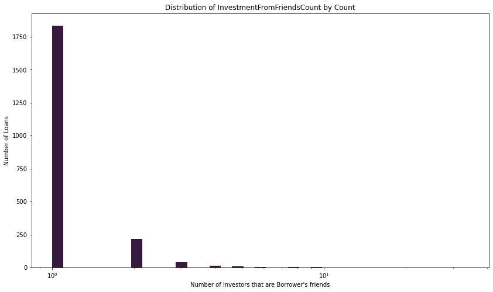

```python
#data = loan_df_subset_copy[loan_df_subset_copy['InvestmentFromFriendsCount'] < 10]
plt.figure(figsize=(14,8))
log10_histogram(x='InvestmentFromFriendsCount', xlabel = 'Number of Investors that are Borrower\'s friends',binsize=1.1)
```

### Discuss the distribution(s) of your variable(s) of interest. Were there any unusual points? Did you need to perform any transformations?

> Wow! Up to 272 Borrowers borrowed 10 times more than their incomes. Some Prosper Loan Borrowers are heavily indebted!!. They are the exception and not the rule. What are their credit ratings? Are they not to be downgraded? Could we help them change their habits by exploring further on why they are so indebted? This could also help us find ways to protect Investor funds.

> Majority of the interest rates fell between 10% (0.1) per annum and just above 30% per annum Interestingly, there is a huge spike in the number of loans charged at an interest rate of just about 32% (about 5000 loans). This spike also corresponded with a spike in the number of loans charged at an Annual Percentage Rate of about 35% per annum (about 6000 loans). Outliers: APRs of less than 5% seem to be negative outliers and those above about 40% are positive outliers. However, the number of loans in these categories are negligible when compared to the majority. Further questions surround the phenomenom of the spikes in numbers at above 30% rates. These ought to be further explored.

### Of the features you investigated, were there any unusual distributions? Did you perform any operations on the data to tidy, adjust, or change the form of the data? If so, why did you do this?

> Variables like EmploymentStatus, LoanStatus, and IncomeRanges were changed to Categorical Types among others.

> The following cleaning operations were done among others:
> - Converted ListingCreationDate into the DateTime format.
> - Merged the columns CreditGrade, ProsperRating (numeric), and ProsperRating (Alpha) into one column
> - Modified the column name and datatype of ListingCategory (numeric).
> - Converted nan values in EmploymentStatus to 'Other'.
> - Converted LoanStatus and EmploymentStatus to categorical data type.